# 存活分析 (Survival Analysis)

作者

Lee, Tsung-Yu

# 1 Survival analysis in R

這份教學講義將介紹存活分析（Survival Analysis）的基本概念，以及如何利用 R 語言進行分析與視覺化。

在醫學研究中，研究者常關心病患的存活時間；在工程領域中，則可能關心產品故障時間；在商業分析中，則可能關心客戶流失時間。這類資料的存活與否與時間相關，因此需要運用專門的統計方法-存活分析。

## 1.1 Part 1: Introduction to Survival Analysis

存活分析是一種研究「事件發生時間（Time-to-Event）」的統計方法。 常見事件包括：病患死亡、癌症復發、機器故障、客戶流失、信用違約

存活分析最重要的特色在於： 1. 關注事件發生時間 2. 能處理設限資料（Censored Data）

### 1.1.1 存活函數

存活函數定義為：

$$S(t)=P(T>t)$$

表示個體在時間 $t$ 之後仍然存活的機率。

### 1.1.2 風險函數 (Hazard Function)

風險函數描述：個體已經存活到時間 $t$ 時，在下一個極短時間內發生事件的瞬時風險。 表示為：

$$h(t)$$

醫學研究中常將其解釋為死亡風險。

### 1.1.3 設限資料（Censoring）

存活資料最重要的特性之一為設限。

例如：

- 病患尚未死亡便結束追蹤
- 研究期間失去聯絡
- 提前退出研究

此時只知道：
$$T > t$$

而不知道實際事件發生時間。

## 1.2 Kaplan-Meier

Kaplan-Meier（KM）方法是一種非參數存活分析方法。

主要用途： - 估計存活曲線 - 描述存活機率變化 - 比較不同群體存活情況

### 1.2.1 Kaplan-Meier 估計式

KM估計量：
$$\prod_{i\le t}
\left(
1-\frac{d_i}{n_i}
\right)$$

其中： $d_i$：事件數 $n_i$：風險集合人數

```r
library(survival)
data(lung)
fit_km <- survfit(Surv(time, status == 2) ~ 1, data = lung)
summary(fit_km)
```

```
Call: survfit(formula = Surv(time, status == 2) ~ 1, data = lung)

 time n.risk n.event survival std.err lower 95% CI upper 95% CI
    5    228       1   0.9956 0.00438       0.9871        1.000
   11    227       3   0.9825 0.00869       0.9656        1.000
   12    224       1   0.9781 0.00970       0.9592        0.997
   13    223       2   0.9693 0.01142       0.9472        0.992
   15    221       1   0.9649 0.01219       0.9413        0.989
   26    220       1   0.9605 0.01290       0.9356        0.986
   30    219       1   0.9561 0.01356       0.9299        0.983
   31    218       1   0.9518 0.01419       0.9243        0.980
   53    217       2   0.9430 0.01536       0.9134        0.974
   54    215       1   0.9386 0.01590       0.9079        0.970
   59    214       1   0.9342 0.01642       0.9026        0.967
   60    213       2   0.9254 0.01740       0.8920        0.960
```

[output cut: 127 more lines]

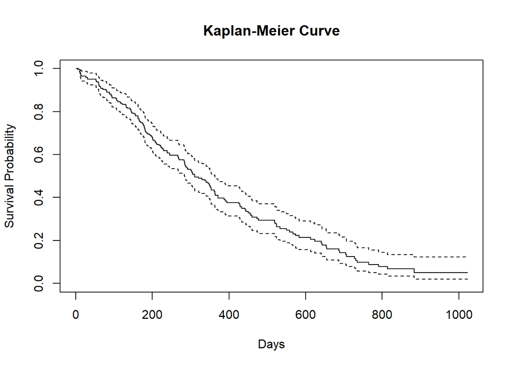

```r
plot( fit_km, xlab = "Days", ylab = "Survival Probability", main = "Kaplan-Meier Curve" )
```

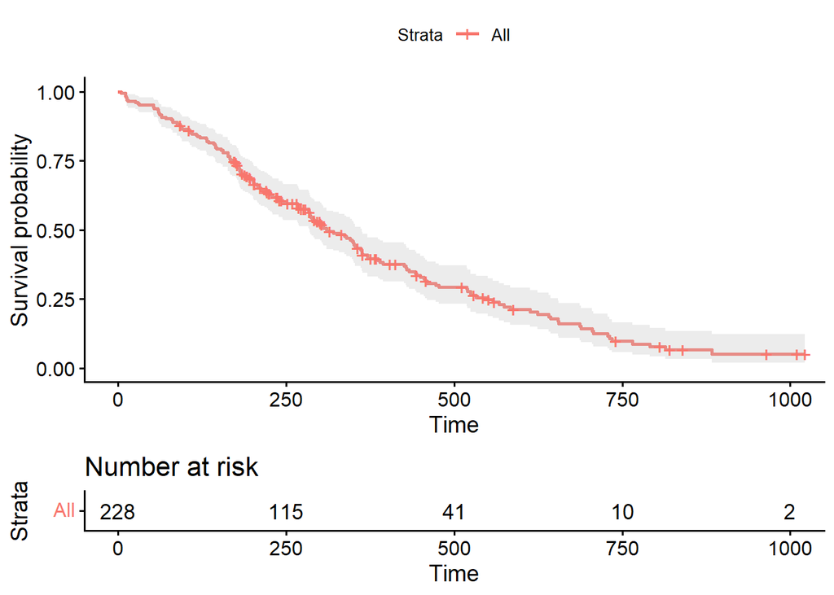

```r
library(survminer)
ggsurvplot( fit_km, risk.table = TRUE, conf.int = TRUE, pval = FALSE )
```

## 1.3 Cox Regression

Kaplan-Meier只能比較群組差異。

若希望同時考慮自變數，例如：年齡、性別、治療方式等等，則需要使用 Cox Regression。

### 1.3.1 Cox模型公式

$$h_0(t)e^{\beta X}$$

其中：

$h_0(t)$：基準風險函數 $\beta$：迴歸係數

Hazard Ratio

Cox模型最常解釋的指標為：

$$HR=e^\beta$$

若：

- HR > 1：風險增加
- HR < 1：風險降低
- HR = 1：無影響

```r
cox_model <- coxph(Surv(time, status == 2) ~ age + sex, data = lung)

summary(cox_model)
```

```
Call:
coxph(formula = Surv(time, status == 2) ~ age + sex, data = lung)

  n= 228, number of events= 165

         coef exp(coef)  se(coef)      z Pr(>|z|)
age  0.017045  1.017191  0.009223  1.848  0.06459 .
sex -0.513219  0.598566  0.167458 -3.065  0.00218 **
---
Signif. codes:  0 '***' 0.001 '**' 0.01 '*' 0.05 '.' 0.1 ' ' 1

    exp(coef) exp(-coef) lower .95 upper .95
age    1.0172     0.9831    0.9990    1.0357
sex    0.5986     1.6707    0.4311    0.8311

Concordance= 0.603  (se = 0.025 )
Likelihood ratio test= 14.12  on 2 df,   p=9e-04
Wald test            = 13.47  on 2 df,   p=0.001
Score (logrank) test = 13.72  on 2 df,   p=0.001
```

## 1.4 Log rank test

若有兩組病患：

- 治療組
- 對照組

肉眼看圖可能覺得有差異，但需要統計檢定確認。

虛無假設：

$$H_0:
S_1(t)=S_2(t)$$

對立假設：

$$H_1:
S_1(t)\neq S_2(t)$$

```r
survdiff( Surv(time, status == 2) ~ sex, data = lung )
```

```
Call:
survdiff(formula = Surv(time, status == 2) ~ sex, data = lung)

        N Observed Expected (O-E)^2/E (O-E)^2/V
sex=1 138      112     91.6      4.55      10.3
sex=2  90       53     73.4      5.68      10.3

 Chisq= 10.3  on 1 degrees of freedom, p= 0.001
```

## 1.5 Example: `lung` dataset

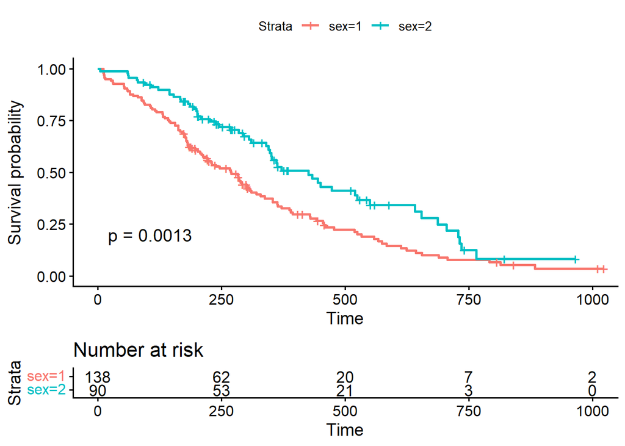

```r
data(lung)
km_sex <- survfit(Surv(time, status == 2) ~ sex, data = lung)
ggsurvplot(km_sex, data = lung, risk.table = TRUE, pval = TRUE)
```

```r
survdiff(Surv(time, status == 2) ~ sex, data = lung)
```

```
Call:
survdiff(formula = Surv(time, status == 2) ~ sex, data = lung)

        N Observed Expected (O-E)^2/E (O-E)^2/V
sex=1 138      112     91.6      4.55      10.3
sex=2  90       53     73.4      5.68      10.3

 Chisq= 10.3  on 1 degrees of freedom, p= 0.001
```

```r
cox_fit <- coxph(Surv(time, status == 2) ~ age + sex + ph.ecog, data = lung)
summary(cox_fit)
```

```
Call:
coxph(formula = Surv(time, status == 2) ~ age + sex + ph.ecog,
    data = lung)

  n= 227, number of events= 164
   (1 observation deleted due to missingness)

             coef exp(coef)  se(coef)      z Pr(>|z|)
age      0.011067  1.011128  0.009267  1.194 0.232416
sex     -0.552612  0.575445  0.167739 -3.294 0.000986 ***
ph.ecog  0.463728  1.589991  0.113577  4.083 4.45e-05 ***
---
Signif. codes:  0 '***' 0.001 '**' 0.01 '*' 0.05 '.' 0.1 ' ' 1

        exp(coef) exp(-coef) lower .95 upper .95
age        1.0111     0.9890    0.9929    1.0297
sex        0.5754     1.7378    0.4142    0.7994
ph.ecog    1.5900     0.6289    1.2727    1.9864

Concordance= 0.637  (se = 0.025 )
Likelihood ratio test= 30.5  on 3 df,   p=1e-06
Wald test            = 29.93  on 3 df,   p=1e-06
Score (logrank) test = 30.5  on 3 df,   p=1e-06
```

若想要更漂亮的風格，以下介紹各功能。

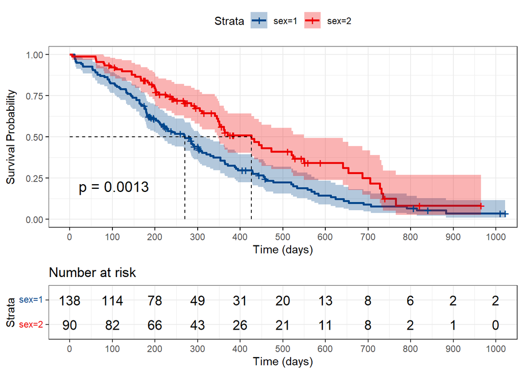

```r
fit <- survfit(Surv(time, status == 2) ~ sex, data = lung)
ggsurvplot(fit, data = lung,
           conf.int = TRUE, # 增加95%信賴水準的陰影區間, c(FALSE, TRUE, 0.90, 0.99)
           pval = TRUE, # 顯示 Log-rank test p-value
           risk.table = TRUE, # 顯示下方的Risk table
           risk.table.height = 0.30, # Risk table 占整張圖的比例
           break.time.by = 100, # x-axis 每100天顯示一個刻度。
           xlab = "Time (days)", ylab = "Survival Probability",
           palette = "lancet",
           surv.median.line = "hv", # 標示中位存活時間 (median survival time) 的位置線
           ggtheme = theme_bw() # 白底黑框
)
```

## 1.6 小結

本講義介紹了：

1. 存活分析基本概念
2. Kaplan-Meier 方法
3. Cox Regression
4. Log-rank Test
5. lung 資料集實作